# `health.csv` Codebook

The data set is at the **state level**, so that each row of the data set represents one state. The data are for September 2013.

## Load Data

```r
# load packages
library(readr)  # for read_csv()
library(dplyr)  # for data manipulation
```

```r
library(ggplot2)  # for plotting
# load data
health <- read_csv("data/health.csv")

# quick look at data
glimpse(health)
```

```
## Observations: 50
## Variables:
## $ state                        (chr) "Alabama", "Alaska", "Arizona", "...
## $ state_abbr                   (chr) "AL", "AK", "AZ", "AR", "CA", "CO...
## $ gov_party                    (chr) "Repubican Governor", "Repubican ...
## $ sen_party                    (chr) "Republican Senate", "Republican ...
## $ house_party                  (chr) "Republican House", "Republican H...
## $ percent_favorable_aca        (dbl) 38.2711, 37.4428, 39.6722, 36.162...
## $ percent_supporting_expansion (dbl) 57.7616, 47.4247, 53.2125, 54.438...
## $ obama_share_12               (dbl) 38.7838, 42.6847, 45.3866, 37.845...
## $ ideology                     (dbl) 0.2440440, 0.0472331, 0.1048640, ...
## $ percent_uninsured            (int) 14, 19, 18, 18, 19, 15, 8, 10, 21...
## $ infant_mortality_rate        (dbl) 9.2, 6.5, 6.4, 7.6, 5.1, 6.2, 6.1...
## $ cancer_incidence             (dbl) 472.9, 451.4, 387.1, 426.7, 434.0...
## $ heart_disease_death_rate     (dbl) 236.0, 151.5, 146.7, 222.5, 161.9...
## $ life_expectancy              (dbl) 75.4, 78.3, 79.6, 76.0, 80.8, 80....
## $ leg_party                    (chr) "Unified Republican Legislature",...
## $ health_score                 (dbl) -2.0999900, 0.0484103, 0.6444630,...
## $ health_score_cat             (chr) "Bottom Tercile", "Middle Tercile...
```

## Variable Descriptions

### `state`: State

- Coding: The name of the state.
- Type: character

```r
# print state names
with(health, print(state))
```

```
##  [1] "Alabama"        "Alaska"         "Arizona"        "Arkansas"
##  [5] "California"     "Colorado"       "Connecticut"    "Delaware"
##  [9] "Florida"        "Georgia"        "Hawaii"         "Idaho"
## [13] "Illinois"       "Indiana"        "Iowa"           "Kansas"
## [17] "Kentucky"       "Louisiana"      "Maine"          "Maryland"
## [21] "Massachusetts"  "Michigan"       "Minnesota"      "Mississippi"
## [25] "Missouri"       "Montana"        "Nebraska"       "Nevada"
## [29] "New Hampshire"  "New Jersey"     "New Mexico"     "New York"
## [33] "North Carolina" "North Dakota"   "Ohio"           "Oklahoma"
## [37] "Oregon"         "Pennsylvania"   "Rhode Island"   "South Carolina"
## [41] "South Dakota"   "Tennessee"      "Texas"          "Utah"
## [45] "Vermont"        "Virginia"       "Washington"     "West Virginia"
## [49] "Wisconsin"      "Wyoming"
```

### `state_abbr`: State Abbreviation

- Coding: The state’s two-letter abbreviation.
- Type: character

```r
# print abbreviations with state names
with(health, cbind(state, state_abbr))
```

```
##       state            state_abbr
##  [1,] "Alabama"        "AL"
##  [2,] "Alaska"         "AK"
##  [3,] "Arizona"        "AZ"
##  [4,] "Arkansas"       "AR"
##  [5,] "California"     "CA"
##  [6,] "Colorado"       "CO"
##  [7,] "Connecticut"    "CT"
##  [8,] "Delaware"       "DE"
##  [9,] "Florida"        "FL"
## [10,] "Georgia"        "GA"
## [11,] "Hawaii"         "HI"
## [12,] "Idaho"          "ID"
## [13,] "Illinois"       "IL"
## [14,] "Indiana"        "IN"
```

[output cut: 36 more lines]

### `gov_party`: Governor’s Party

- Coding: The political party of the governor.
- Type: character

```r
# convert to factor
health <- mutate(health, gov_party = factor(gov_party, levels = c("Republican Governor",
                                                                  "Independent Governor",
                                                                  "Democratic Governor")))
# table
with(health, table(gov_party))
```

```
## gov_party
##  Republican Governor Independent Governor  Democratic Governor
##                    0                    1                   19
```

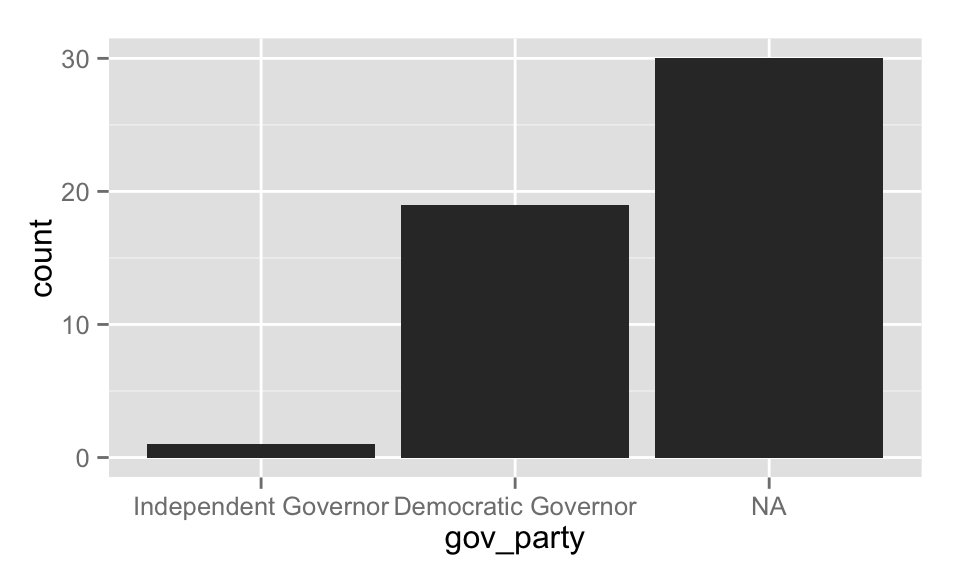

```r
# barplot
qplot(gov_party, data = health)
```

### `sen_party`: Senate Majority Party

- Coding: The majority party in the state senate.
- Type: character

```r
# convert to factor
health <- mutate(health, sen_party = factor(sen_party, levels = c("Republican Senate",
                                                                  "Tied Senate",
                                                                  "Democratic Senate")))
# table
with(health, table(sen_party))
```

```
## sen_party
## Republican Senate       Tied Senate Democratic Senate
##                30                 1                19
```

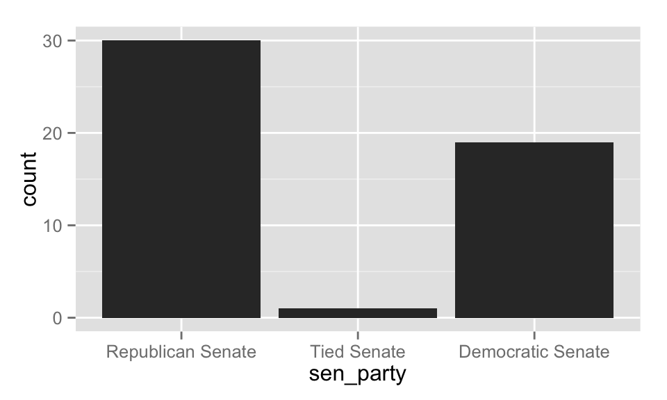

```r
# barplot
qplot(sen_party, data = health)
```

### `house_party`: House Majority Party

```r
# convert to factor
health <- mutate(health, house_party = factor(house_party, levels = c("Republican House",
                                                                      "Tied House",
                                                                      "Democratic House")))
# table
with(health, table(house_party))
```

```
## house_party
## Republican House       Tied House Democratic House
##               29                0               21
```

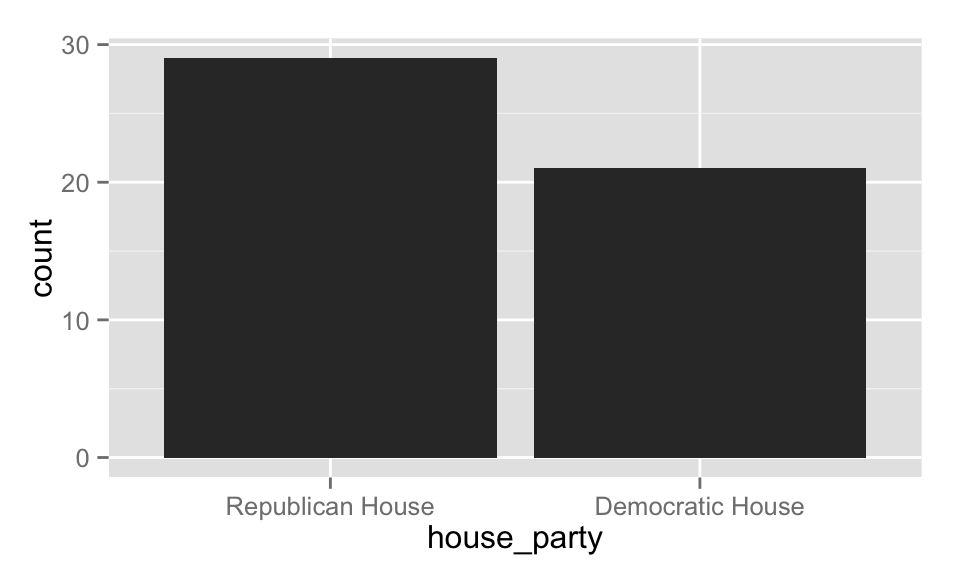

```r
# barplot
qplot(house_party, data = health)
```

### `leg_party`: Party in Control of Legislature

- Coding: Indicates where the Republicans or Democrats are the majority in *both* the house and the senate, or whether the legislature is divided.
- Type: character

```r
# convert to factor
health <- mutate(health,
                 leg_party = factor(leg_party,
                                      levels = c("Unified Republican Legislature",
                                                 "Divided Legislature",
                                                 "Unified Democratic Legislature")))
# table
with(health, table(leg_party))
```

```
## leg_party
## Unified Republican Legislature            Divided Legislature
##                             27                              5
## Unified Democratic Legislature
##                             18
```

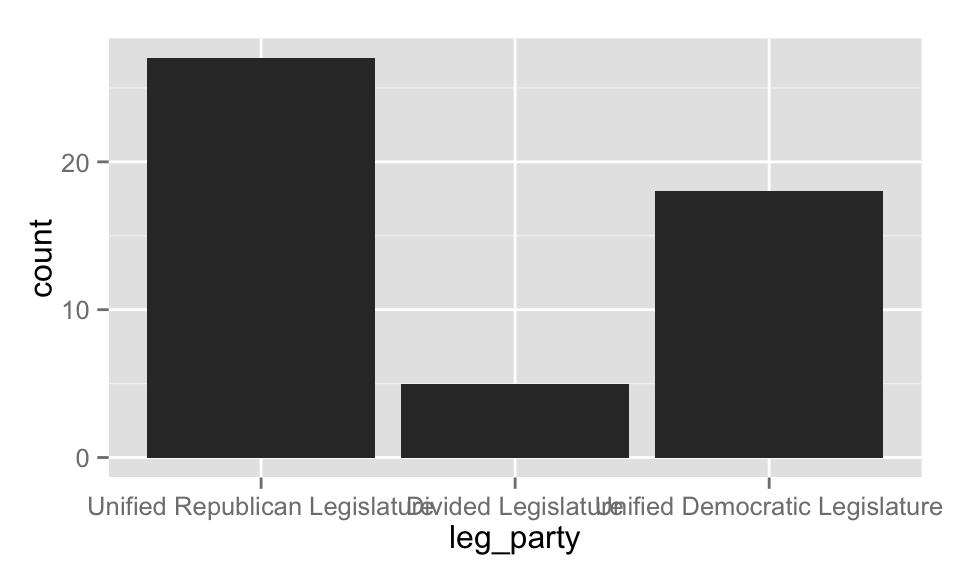

```r
# barplot
qplot(leg_party, data = health)
```

### `percent_favorable_aca`: Percent Favorable to ACA

- Coding: The percent of a state’s population with a favorable opinion toward the Affordable Care Act. See Barrilleaux and Rainey (2014) for the details.
- Type: double

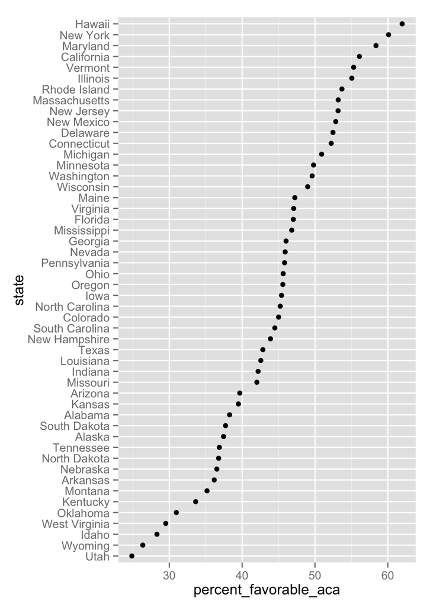

```r
# order factor district by percent_favorable_aca
health <- mutate(health, state = reorder(state, percent_favorable_aca))

# dotplot
ggplot(health, aes(percent_favorable_aca, state)) + geom_point()
```

### `percent_supporting_expansion`: Percent Suporting the Medicaid Expansion

- Coding: The percent of a state’s population that support expanding their Medicaid problem as allowed (originally required) by the Affordable Care Act. See Barrilleaux and Rainey (2014) for the details.
- Type: double

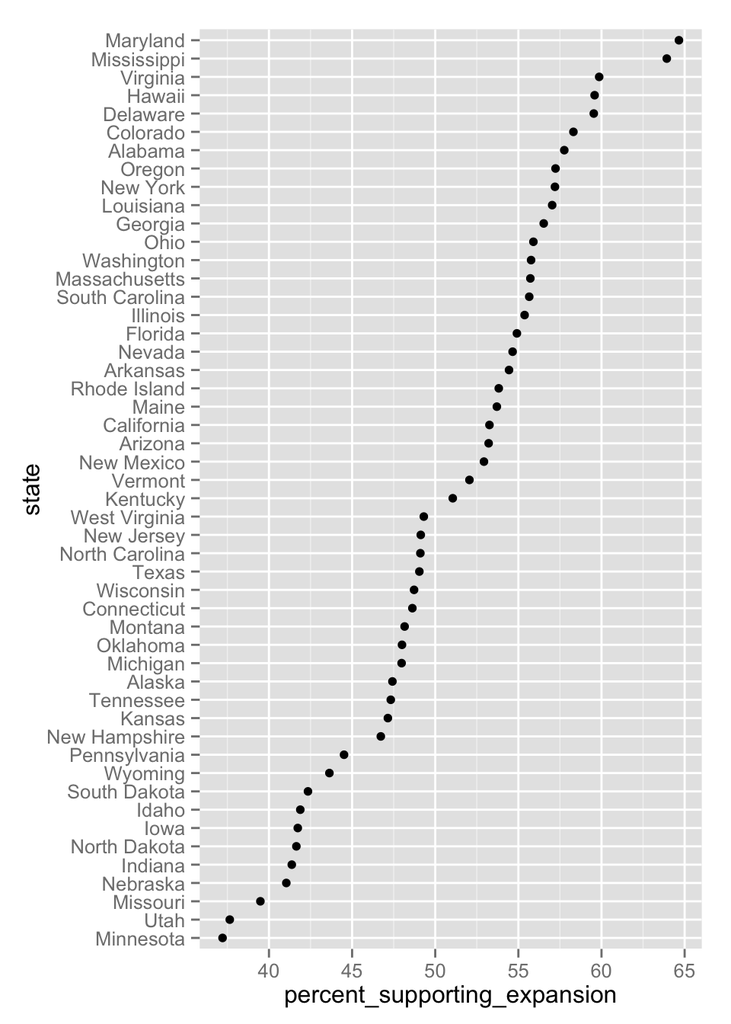

```r
# order factor district by percent_supporting_expansion
health <- mutate(health, state = reorder(state, percent_supporting_expansion))

# dotplot
ggplot(health, aes(percent_supporting_expansion, state)) + geom_point()
```

### `ideology`: Ideology

- Coding: Continuous measure of state ideology. Created by Chris Tausanovitch and Christopher Warshaw. The details and data are available at the [American Ideology Project](http://www.americanideologyproject.com/).
- Type: double

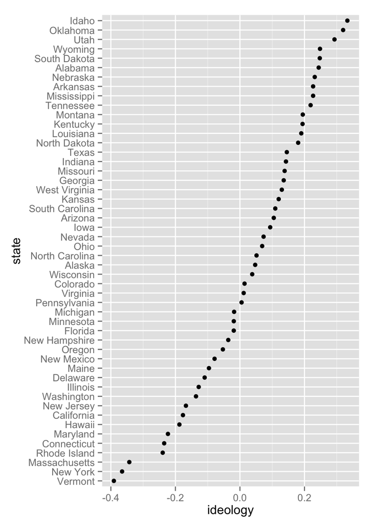

```r
# order factor district by ideology
health <- mutate(health, state = reorder(state, ideology))

# dotplot
ggplot(health, aes(ideology, state)) + geom_point()
```

### `percent_uninsured`: Percent without Health Insurance

- Coding: Percent of the state’s population without health insurance.
- Type: integer

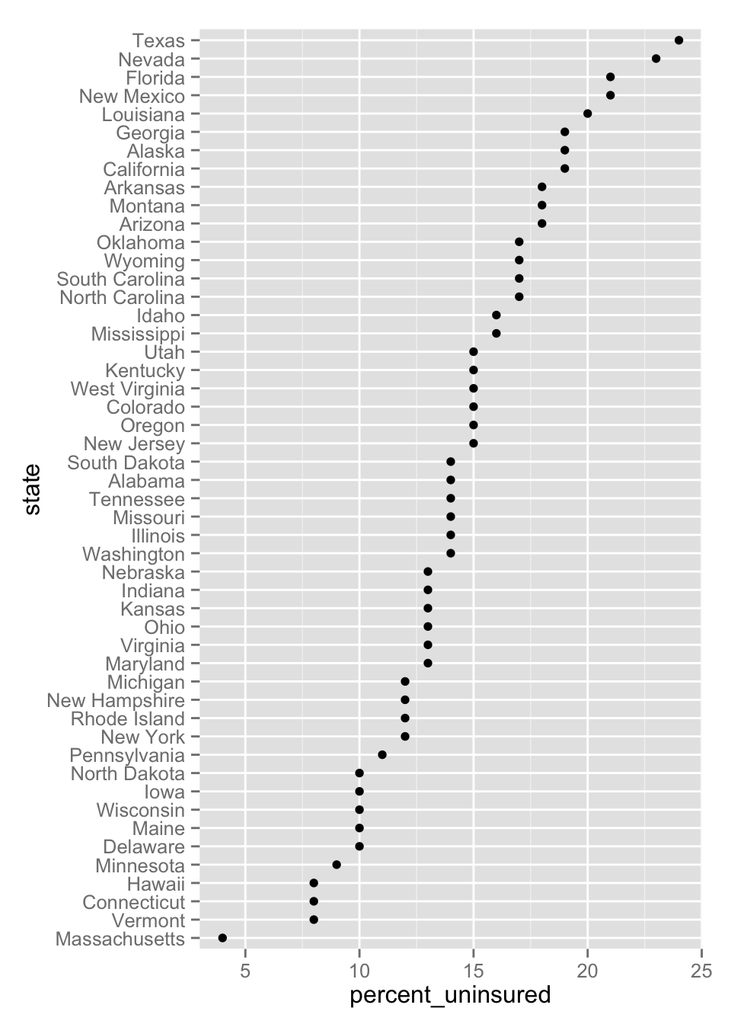

```r
# order factor district by percent_uninsured
health <- mutate(health, state = reorder(state, percent_uninsured))

# dotplot
ggplot(health, aes(percent_uninsured, state)) + geom_point()
```

### `infant_mortality_rate`: Infant Mortality Rate

- Coding: The number of infant deaths (less than one year old) per 1,000 live births in 2010.
- Type: double

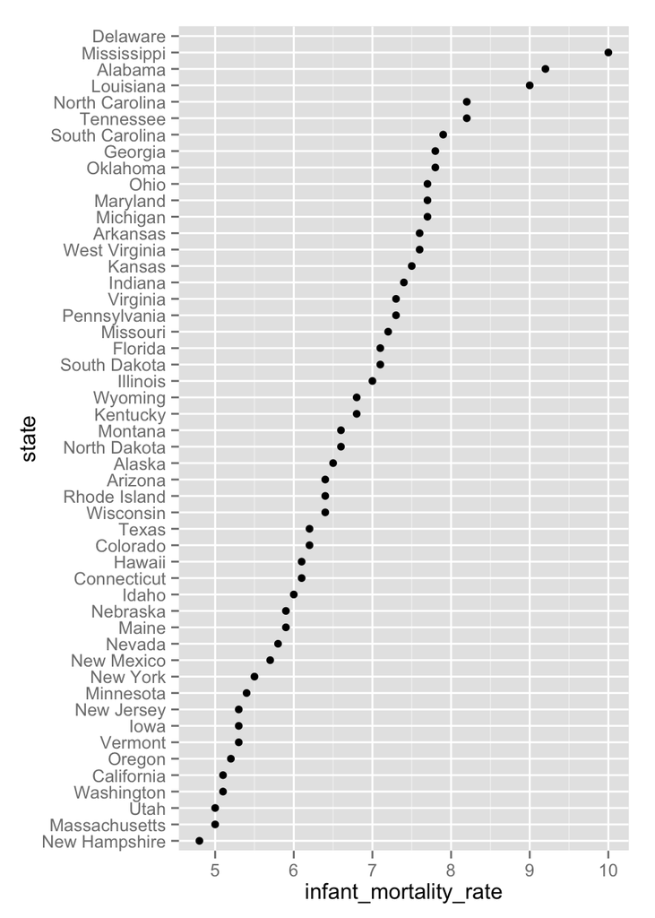

```r
# order factor district by infant_mortality_rate
health <- mutate(health, state = reorder(state, infant_mortality_rate))

# dotplot
ggplot(health, aes(infant_mortality_rate, state)) + geom_point()
```

### `cancer_incidence`: Age-Adjusted Cancer Incidence Rate

- Coding: the age-adjusted cancer incidence rate per 100,000 in 2009.
- Type: double

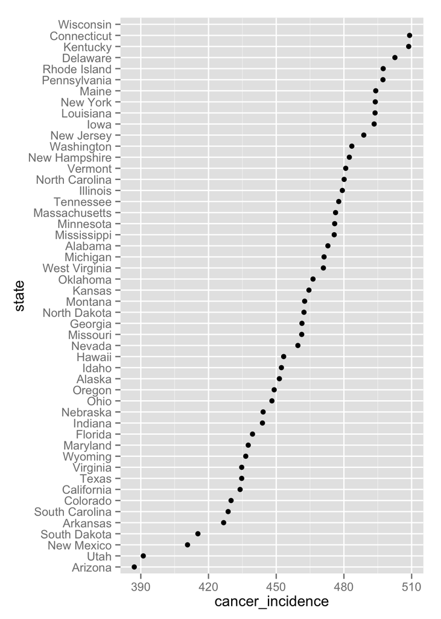

```r
# order factor district by cancer_incidence
health <- mutate(health, state = reorder(state, cancer_incidence))

# dotplot
ggplot(health, aes(cancer_incidence, state)) + geom_point()
```

### `heart_disease_death_rate`: Heart Disease Death Rate

- Coding: The age-adjusted number of deaths due to heart disease per 100,000 in 2010.
- Type: double

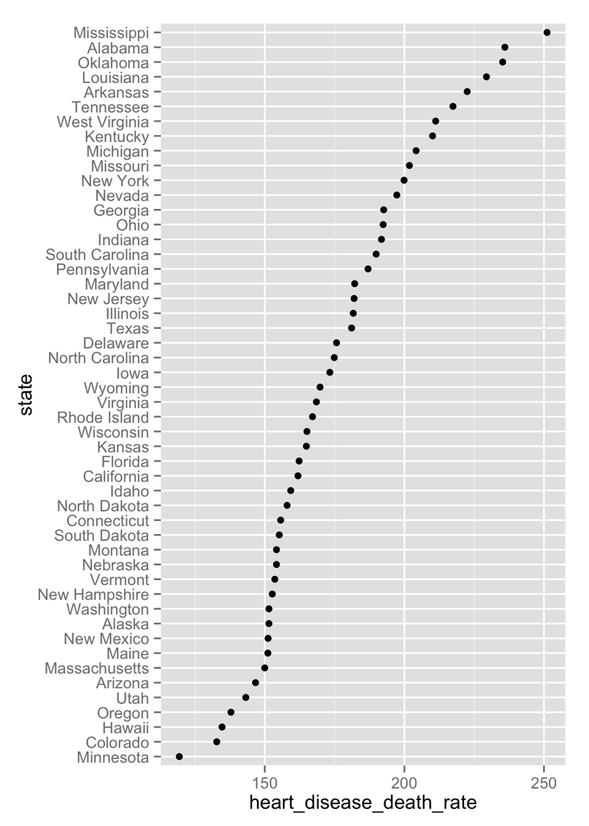

```r
# order factor district by heart_disease_death_rate
health <- mutate(health, state = reorder(state, heart_disease_death_rate))

# dotplot
ggplot(health, aes(heart_disease_death_rate, state)) + geom_point()
```

### `life_expectancy`: Life Expectancy

- Coding: The life expectancy at birth in 2010.
- Type: double

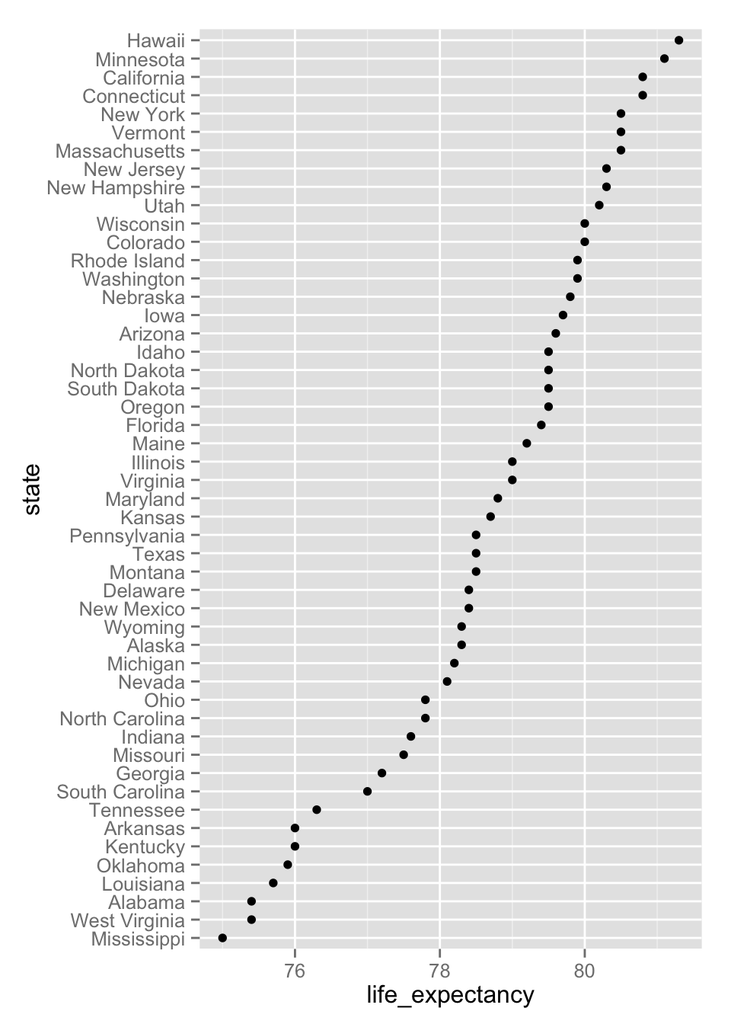

```r
# order factor district by life_expectancy
health <- mutate(health, state = reorder(state, life_expectancy))

# dotplot
ggplot(health, aes(life_expectancy, state)) + geom_point()
```

### `health_score`: Overall Health Score

- Coding: An overall health score created by combining the variables `infant_mortality_rate`, `cancer_incidence`, `heart_disease_death_rate`, and `life_expectancy` using factor analysis. Higher values indicate a more healthy state.
- Type: double

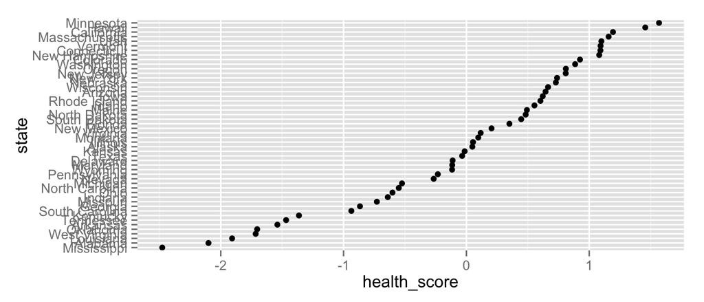

```r
# order factor district by life_expectancy
health <- mutate(health, state = reorder(state, health_score))

# dotplot
ggplot(health, aes(health_score, state)) + geom_point()
```

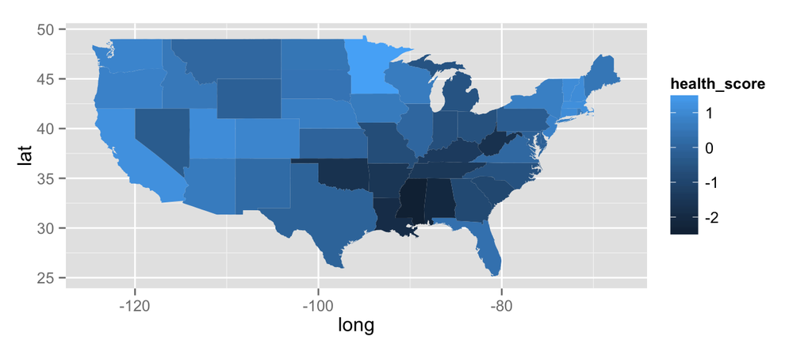

```r
# plot map
## load map data
states <- map_data("state")
## create lower-case version of variable state for merging with data frame states
health <- mutate(health, region = tolower(state))
## merge states and health data frame to choro
choro <- merge(states, health, by = "region")
choro <- choro[order(choro$order), ]
## plot map
qplot(long, lat, data = choro, group = group,
      fill = health_score, geom = "polygon")
```

### `health_score_cat`: Categorical Health Score

- Coding: Divided the variable `health_score` into the bottom, middle, and top terciles (third)
- Type: character

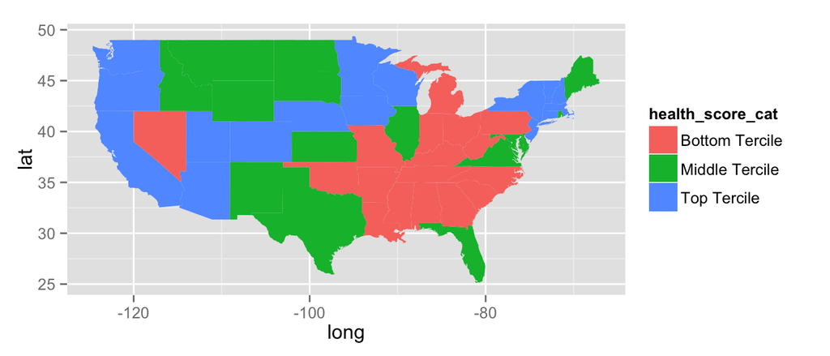

```r
# change health_score_cat to factor
health <- mutate(health, health_score_cat = factor(health_score_cat,
                                                   levels = c("Bottom Tercile",
                                                              "Middle Tercile",
                                                              "Top Tercile")))

# plot map
qplot(long, lat, data = choro, group = group,
      fill = health_score_cat, geom = "polygon")
```